# gapminer plot

tai

2016年3月18日

#### This plot would like to ask the correlation of GDP, life expectancy and population in different continent (in plot fig.1). The results show that life expectancy (x-axis) has a great correlation with GDP (y axis, log), and the populations of different countries are represented by the sizes of dots. There would be more low life expectancy or GDP countries in Africa and Asia, especially in Africa, many countries are both low. Those countries has most population are in Asia, they has may have lower GDP, but the life expectancy would be relation to population in those countries. The all results from all continents are demonstrated in fig.2. Both high GDP and life expectancy countries mainly are in America, Europe and Oceania.

require package: ggplot2, devtool, rio

```r
library(ggplot2)
library("devtools")
install_github("leeper/rio")
```

```
## Skipping install for github remote, the SHA1 (ea992437) has not changed since last install.
##   Use `force = TRUE` to force installation
```

```r
library("rio")
```

get the gapminder profile: import is a function in package of need devtool and rio

```r
gapminder <- import("https://raw.githubusercontent.com/resbaz/r-novice-gapminder-files/master/data/gapminder-FiveYearData.csv")
```

correlation of population size, GDP and life expectency in different continent fig (1)

```r
gap_graphic1 <- qplot(lifeExp, gdpPercap, data = gapminder, size = pop, color=continent) + scale_y_log10() +facet_wrap( ~ continent)+ scale_size_area(max_size = 8)
```

run the plot fig (1)

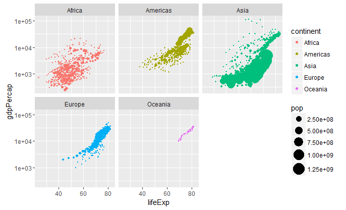

correlation of population size, GDP and life expectency in different continent fig (2)

```r
gap_graphic2 <- qplot(lifeExp, gdpPercap, data = gapminder, size = pop, color=continent) + scale_y_log10() + scale_size_area(max_size = 15)
```

run the plot fig (2)

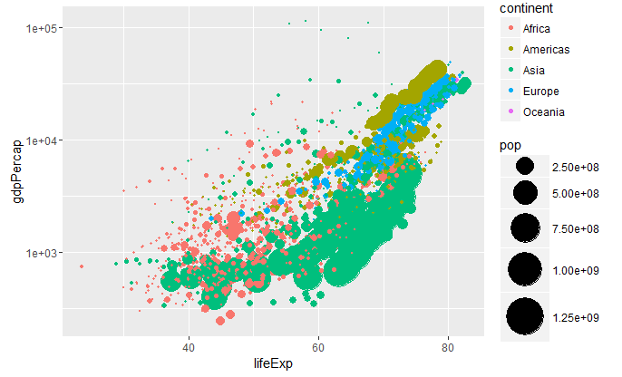